# Dataset

Using data from "The Ryerson Audio-Visual Database of Emotional Speech and Song (RAVDESS)" by Livingstone & Russo is licensed under CC BY-NA-SC 4.0.

https://zenodo.org/record/1188976

The file is **Audio_Speech_Actors_01-24**

## Data Organization

Check out our Kaggle Speech emotion dataset.

Files

File naming convention

Filename identifiers

- Modality (01 = full-AV, 02 = video-only, 03 = audio-only).
- Vocal channel (01 = speech, 02 = song).
- Emotion (01 = neutral, 02 = calm, 03 = happy, 04 = sad, 05 = angry, 06 = fearful, 07 = disgust, 08 = surprised).
- Emotional intensity (01 = normal, 02 = strong). NOTE: There is no strong intensity for the 'neutral' emotion.
- Statement (01 = "Kids are talking by the door", 02 = "Dogs are sitting by the door").
- Repetition (01 = 1st repetition, 02 = 2nd repetition).
- Actor (01 to 24. Odd numbered actors are male, even numbered actors are female).

Filename example: 03-02-06-01-02-01-12.wav

- Audio-only (03)
- Song (02)
- Fearful (06)
- Normal intensity (01)
- Statement "dogs" (02)
- 1st Repetition (01)
- 12th Actor (12)
- Female, as the actor ID number is even.

How to cite the RAVDESS

Academic citation

If you use the RAVDESS in an academic publication, please use the following citation: Livingstone SR, Russo FA (2018) The Ryerson Audio-Visual Database of Emotional Speech and Song (RAVDESS): A dynamic, multimodal set of facial and vocal expressions in North American English. PLoS ONE 13(5): e0196391. https://doi.org/10.1371/journal.pone.0196391.

All other attributions

If you use the RAVDESS in a form other than an academic publication, such as in a blog post, school project, or non-commercial product, please use the following attribution: "The Ryerson Audio-Visual Database of Emotional Speech and Song (RAVDESS)" by Livingstone & Russo is licensed under CC BY-NA-SC 4.0.

# Loading Packages

```python
# Imports
import joblib
import numpy as np
import pandas as pd
import matplotlib
import matplotlib.pyplot as plt
import librosa as lr
import librosa.display
import IPython.display as ipd
import seaborn as sns
import xgboost
import sklearn
import h2o
from h2o.automl import H2OAutoML
from glob import glob
from joblib import dump, load
from sklearn.cluster import KMeans
from sklearn.metrics import silhouette_score
from sklearn.decomposition import PCA
from sklearn.preprocessing import StandardScaler
from sklearn.preprocessing import LabelEncoder
from sklearn.model_selection import train_test_split
from xgboost import XGBClassifier
from sklearn.tree import DecisionTreeClassifier
from sklearn.ensemble import RandomForestClassifier
from sklearn.metrics import accuracy_score, confusion_matrix
%matplotlib inline
```

```python
# Package versions
%reload_ext watermark
%watermark --iversions
```

```
matplotlib 3.2.2
pandas     1.0.5
h2o        3.30.0.6
seaborn    0.11.0
librosa    0.7.2
sklearn    0.23.1
xgboost    0.90
numpy      1.18.5
joblib     0.15.1
```

# Loading Data

```python
%%time

# Looping through 24 folders, each with 60 samples, for a total of 1440 audio files.
# The folders are named 'Actor_01' through 'Actor_24'

# Definig the root directory name
root_dir = 'Audio_Speech_Actors_01-24'

# Dictionaries to receive the outputs
files = {}
sampling_rate = {}

# Loop through all directories
for itens in range(1, 25):

    # Define the folder path for that specific actor
    if len(str(itens)) == 1:
        audio_dir = root_dir + '/Actor_' + str('0') + str(itens)
    else:
        audio_dir = root_dir + '/Actor_' + str(itens)

    # Extract the path to all the directory's files
    audio_files = glob(audio_dir + '/*.wav')

    # Store the path and sampling rate for each '.wav' file in the folder
    for i in range(len(audio_files)):
        x = audio_files[i]
        audio, sfreq = lr.load(audio_files[i], sr = None)
        files[x] = len(audio) / sfreq
        sampling_rate[x] = sfreq
```

```
Wall time: 59.3 s
```

```python
# Check if all sampling rates are equal
all(value==48000 for value in sampling_rate.values())
```

```
True
```

```python
# Put everying into a dataframe
audio_df = pd.DataFrame()

for keys, values in files.items():
    audio_df.at[keys,'file_length'] = values

audio_df
```

|  | file_length |
| --- | --- |
| Audio_Speech_Actors_01-24/Actor_01\03-01-01-01-01-01-01.wav | 3.303292 |
| Audio_Speech_Actors_01-24/Actor_01\03-01-01-01-01-02-01.wav | 3.336667 |
| Audio_Speech_Actors_01-24/Actor_01\03-01-01-01-02-01-01.wav | 3.269917 |
| Audio_Speech_Actors_01-24/Actor_01\03-01-01-01-02-02-01.wav | 3.169833 |
| Audio_Speech_Actors_01-24/Actor_01\03-01-02-01-01-01-01.wav | 3.536854 |
| ... | ... |
| Audio_Speech_Actors_01-24/Actor_24\03-01-08-01-02-02-24.wav | 3.403396 |
| Audio_Speech_Actors_01-24/Actor_24\03-01-08-02-01-01-24.wav | 3.937271 |
| Audio_Speech_Actors_01-24/Actor_24\03-01-08-02-01-02-24.wav | 3.970625 |
| Audio_Speech_Actors_01-24/Actor_24\03-01-08-02-02-01-24.wav | 3.670333 |
| Audio_Speech_Actors_01-24/Actor_24\03-01-08-02-02-02-24.wav | 3.636958 |

1440 rows × 1 columns

```python
# Function to extract the audio files and their sampling rates
# This is necessary to obtain the mfcc from an audio file
def extract_audio_data(file):
    audio, sfreq = lr.load(file, sr = None)
    return audio, sfreq
```

```python
# Checking the shape and sampling rates for an audio file
# Their rate (shape / sampling rate) is the file_length
audio, sfreq = extract_audio_data(audio_df.index[1439])
print(f'\nShape of the series representing the audio (y): {audio.shape} \nSampling Rate (sr): {sfreq}')
```

```
Shape of the series representing the audio (y): (174574,)
Sampling Rate (sr): 48000
```

```python
# Function to extract the MFCC from a file
def extract_mfcc(file):
    audio, sfreq = extract_audio_data(file)
    mfccs = librosa.feature.mfcc(audio, sr = sfreq)
    return mfccs
```

```python
extract_mfcc(audio_df.index[0])
```

```
array([[-861.5326, -861.5326, -861.5326, ..., -861.5326, -861.5326,
        -861.5326],
       [   0.    ,    0.    ,    0.    , ...,    0.    ,    0.    ,
           0.    ],
       [   0.    ,    0.    ,    0.    , ...,    0.    ,    0.    ,
           0.    ],
       ...,
       [   0.    ,    0.    ,    0.    , ...,    0.    ,    0.    ,
           0.    ],
       [   0.    ,    0.    ,    0.    , ...,    0.    ,    0.    ,
           0.    ],
       [   0.    ,    0.    ,    0.    , ...,    0.    ,    0.    ,
           0.    ]], dtype=float32)
```

Filename identifiers

- Modality (01 = full-AV, 02 = video-only, 03 = audio-only).
- Vocal channel (01 = speech, 02 = song).
- Emotion (01 = neutral, 02 = calm, 03 = happy, 04 = sad, 05 = angry, 06 = fearful, 07 = disgust, 08 = surprised).
- Emotional intensity (01 = normal, 02 = strong). NOTE: There is no strong intensity for the 'neutral' emotion.
- Statement (01 = "Kids are talking by the door", 02 = "Dogs are sitting by the door").
- Repetition (01 = 1st repetition, 02 = 2nd repetition).
- Actor (01 to 24. Odd numbered actors are male, even numbered actors are female).

Filename example: 03-02-06-01-02-01-12.wav

- Audio-only (03)
- Song (02)
- Fearful (06)
- Normal intensity (01)
- Statement "dogs" (02)
- 1st Repetition (01)
- 12th Actor (12)
- Female, as the actor ID number is even.

```python
%%time

# Create a list to store the identifiers for each audio file
list_data_frame = []

# Loop to extract the identifiers from files
for file_path in audio_df.index:

    # Call function to obtains mfccs
    data = extract_mfcc(file_path)

    # Transform the data to shape (n samples, n features)
    frame = pd.DataFrame(data.T, columns = ['mfcc' + str(x) for x in range (0,20)])

    # Extract actor gender using the encoding
    frame['ID_ACTOR_GENDER'] = file_path[53:55]

    # Exctract emotion using the encoding
    frame['ID_EMOTION'] = file_path[41:43]

    # Extract emotion intensity
    frame['ID_EMOTION_INTENSITY'] = file_path[44:46]

    # Append to the list
    list_data_frame.append(frame)
```

```
Wall time: 48.2 s
```

```python
# Contatenate the list elements into a df
identifiers_df = pd.concat(list_data_frame, ignore_index = True)
```

```python
# Check result
identifiers_df
```

|  | mfcc0 | mfcc1 | mfcc2 | mfcc3 | mfcc4 | mfcc5 | mfcc6 | mfcc7 | mfcc8 | mfcc9 | ... | mfcc13 | mfcc14 | mfcc15 | mfcc16 | mfcc17 | mfcc18 | mfcc19 | ID_ACTOR_GENDER | ID_EMOTION | ID_EMOTION_INTENSITY |
| --- | --- | --- | --- | --- | --- | --- | --- | --- | --- | --- | --- | --- | --- | --- | --- | --- | --- | --- | --- | --- | --- |
| 0 | -861.532593 | 0.000000 | 0.000000 | 0.000000 | 0.000000 | 0.000000 | 0.000000 | 0.000000 | 0.000000 | 0.000000 | ... | 0.000000 | 0.000000 | 0.000000 | 0.000000 | 0.000000 | 0.000000 | 0.000000 | 01 | 01 | 01 |
| 1 | -861.532593 | 0.000000 | 0.000000 | 0.000000 | 0.000000 | 0.000000 | 0.000000 | 0.000000 | 0.000000 | 0.000000 | ... | 0.000000 | 0.000000 | 0.000000 | 0.000000 | 0.000000 | 0.000000 | 0.000000 | 01 | 01 | 01 |
| 2 | -861.532593 | 0.000000 | 0.000000 | 0.000000 | 0.000000 | 0.000000 | 0.000000 | 0.000000 | 0.000000 | 0.000000 | ... | 0.000000 | 0.000000 | 0.000000 | 0.000000 | 0.000000 | 0.000000 | 0.000000 | 01 | 01 | 01 |
| 3 | -861.532593 | 0.000000 | 0.000000 | 0.000000 | 0.000000 | 0.000000 | 0.000000 | 0.000000 | 0.000000 | 0.000000 | ... | 0.000000 | 0.000000 | 0.000000 | 0.000000 | 0.000000 | 0.000000 | 0.000000 | 01 | 01 | 01 |
| 4 | -861.532593 | 0.000000 | 0.000000 | 0.000000 | 0.000000 | 0.000000 | 0.000000 | 0.000000 | 0.000000 | 0.000000 | ... | 0.000000 | 0.000000 | 0.000000 | 0.000000 | 0.000000 | 0.000000 | 0.000000 | 01 | 01 | 01 |
| ... | ... | ... | ... | ... | ... | ... | ... | ... | ... | ... | ... | ... | ... | ... | ... | ... | ... | ... | ... | ... | ... |
| 500281 | -693.609009 | 3.021235 | 3.011289 | 2.994891 | 2.972303 | 2.943882 | 2.910077 | 2.871416 | 2.828496 | 2.781949 | ... | 2.573641 | 2.519586 | 2.466096 | 2.413781 | 2.363167 | 2.314736 | 2.268862 | 24 | 08 | 02 |
| 500282 | -691.884399 | 5.430296 | 5.332271 | 5.174513 | 4.964972 | 4.713866 | 4.432867 | 4.134216 | 3.829843 | 3.530532 | ... | 2.529897 | 2.345227 | 2.186139 | 2.050030 | 1.933901 | 1.835087 | 1.751647 | 24 | 08 | 02 |
| 500283 | -692.399963 | 4.718255 | 4.670175 | 4.591483 | 4.484293 | 4.351463 | 4.196495 | 4.023423 | 3.836677 | 3.640923 | ... | 2.861344 | 2.688585 | 2.531607 | 2.392811 | 2.273795 | 2.175476 | 2.097934 | 24 | 08 | 02 |
| 500284 | -694.268372 | 2.090834 | 2.086926 | 2.080427 | 2.071359 | 2.059744 | 2.045627 | 2.029049 | 2.010061 | 1.988727 | ... | 1.881333 | 1.849386 | 1.815585 | 1.780022 | 1.742835 | 1.704102 | 1.663948 | 24 | 08 | 02 |
| 500285 | -692.471741 | 4.618038 | 4.574526 | 4.505244 | 4.414803 | 4.309120 | 4.195020 | 4.079656 | 3.969994 | 3.872242 | ... | 3.675385 | 3.677577 | 3.694948 | 3.722036 | 3.752502 | 3.779414 | 3.796019 | 24 | 08 | 02 |

500286 rows × 23 columns

```python
# Using ID_ACTOR_GENDER to define LABEL_GENDER
identifiers_df['LABEL_GENDER'] = list(map(lambda x: 'male' if int(x)%2 == 1 else 'female',
                                         identifiers_df.ID_ACTOR_GENDER))
```

```python
# Using ID_EMOTION to define LABEL_EMOTION
identifiers_df['LABEL_EMOTION'] = identifiers_df.ID_EMOTION.map({'01':'neutral',
                                                                 '02':'calm',
                                                                 '03':'happy',
                                                                 '04':'sad',
                                                                 '05':'angry',
                                                                 '06':'fearful',
                                                                 '07':'disgust',
                                                                 '08':'surprised'})
```

```python
# Using ID_EMOTION_INTENSITY to define LABEL_INTENSITY
identifiers_df['LABEL_INTENSITY'] = identifiers_df.ID_EMOTION_INTENSITY.map({'01':'normal',
                                                                             '02':'strong'})
```

```python
# Creating a GENDER + EMOTION label
identifiers_df['LABEL_GENDER_EMOTION'] = identifiers_df['LABEL_GENDER'] + '_' + identifiers_df['LABEL_EMOTION']
```

```python
# Renaming it as df_final
df_final = identifiers_df.copy()
```

```python
df_final
```

|  | mfcc0 | mfcc1 | mfcc2 | mfcc3 | mfcc4 | mfcc5 | mfcc6 | mfcc7 | mfcc8 | mfcc9 | ... | mfcc17 | mfcc18 | mfcc19 | ID_ACTOR_GENDER | ID_EMOTION | ID_EMOTION_INTENSITY | LABEL_GENDER | LABEL_EMOTION | LABEL_INTENSITY | LABEL_GENDER_EMOTION |
| --- | --- | --- | --- | --- | --- | --- | --- | --- | --- | --- | --- | --- | --- | --- | --- | --- | --- | --- | --- | --- | --- |
| 0 | -861.532593 | 0.000000 | 0.000000 | 0.000000 | 0.000000 | 0.000000 | 0.000000 | 0.000000 | 0.000000 | 0.000000 | ... | 0.000000 | 0.000000 | 0.000000 | 01 | 01 | 01 | male | neutral | normal | male_neutral |
| 1 | -861.532593 | 0.000000 | 0.000000 | 0.000000 | 0.000000 | 0.000000 | 0.000000 | 0.000000 | 0.000000 | 0.000000 | ... | 0.000000 | 0.000000 | 0.000000 | 01 | 01 | 01 | male | neutral | normal | male_neutral |
| 2 | -861.532593 | 0.000000 | 0.000000 | 0.000000 | 0.000000 | 0.000000 | 0.000000 | 0.000000 | 0.000000 | 0.000000 | ... | 0.000000 | 0.000000 | 0.000000 | 01 | 01 | 01 | male | neutral | normal | male_neutral |
| 3 | -861.532593 | 0.000000 | 0.000000 | 0.000000 | 0.000000 | 0.000000 | 0.000000 | 0.000000 | 0.000000 | 0.000000 | ... | 0.000000 | 0.000000 | 0.000000 | 01 | 01 | 01 | male | neutral | normal | male_neutral |
| 4 | -861.532593 | 0.000000 | 0.000000 | 0.000000 | 0.000000 | 0.000000 | 0.000000 | 0.000000 | 0.000000 | 0.000000 | ... | 0.000000 | 0.000000 | 0.000000 | 01 | 01 | 01 | male | neutral | normal | male_neutral |
| ... | ... | ... | ... | ... | ... | ... | ... | ... | ... | ... | ... | ... | ... | ... | ... | ... | ... | ... | ... | ... | ... |
| 500281 | -693.609009 | 3.021235 | 3.011289 | 2.994891 | 2.972303 | 2.943882 | 2.910077 | 2.871416 | 2.828496 | 2.781949 | ... | 2.363167 | 2.314736 | 2.268862 | 24 | 08 | 02 | female | surprised | strong | female_surprised |
| 500282 | -691.884399 | 5.430296 | 5.332271 | 5.174513 | 4.964972 | 4.713866 | 4.432867 | 4.134216 | 3.829843 | 3.530532 | ... | 1.933901 | 1.835087 | 1.751647 | 24 | 08 | 02 | female | surprised | strong | female_surprised |
| 500283 | -692.399963 | 4.718255 | 4.670175 | 4.591483 | 4.484293 | 4.351463 | 4.196495 | 4.023423 | 3.836677 | 3.640923 | ... | 2.273795 | 2.175476 | 2.097934 | 24 | 08 | 02 | female | surprised | strong | female_surprised |
| 500284 | -694.268372 | 2.090834 | 2.086926 | 2.080427 | 2.071359 | 2.059744 | 2.045627 | 2.029049 | 2.010061 | 1.988727 | ... | 1.742835 | 1.704102 | 1.663948 | 24 | 08 | 02 | female | surprised | strong | female_surprised |
| 500285 | -692.471741 | 4.618038 | 4.574526 | 4.505244 | 4.414803 | 4.309120 | 4.195020 | 4.079656 | 3.969994 | 3.872242 | ... | 3.752502 | 3.779414 | 3.796019 | 24 | 08 | 02 | female | surprised | strong | female_surprised |

500286 rows × 27 columns

```python
df_final.dtypes
```

```
mfcc0                   float32
mfcc1                   float32
mfcc2                   float32
mfcc3                   float32
mfcc4                   float32
mfcc5                   float32
mfcc6                   float32
mfcc7                   float32
mfcc8                   float32
mfcc9                   float32
mfcc10                  float32
mfcc11                  float32
mfcc12                  float32
mfcc13                  float32
mfcc14                  float32
mfcc15                  float32
mfcc16                  float32
mfcc17                  float32
mfcc18                  float32
mfcc19                  float32
ID_ACTOR_GENDER          object
ID_EMOTION               object
ID_EMOTION_INTENSITY     object
LABEL_GENDER             object
LABEL_EMOTION            object
LABEL_INTENSITY          object
LABEL_GENDER_EMOTION     object
dtype: object
```

# Exploratory Analysis

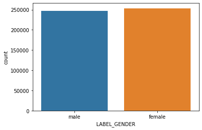

```python
# Dataset balance by gender
sns.countplot(x = 'LABEL_GENDER', data = df_final)
```

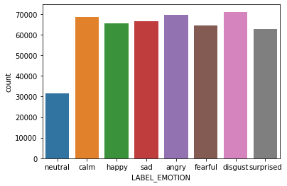

```python
# Dataset balance by emotion
sns.countplot(x = 'LABEL_EMOTION', data = df_final)
```

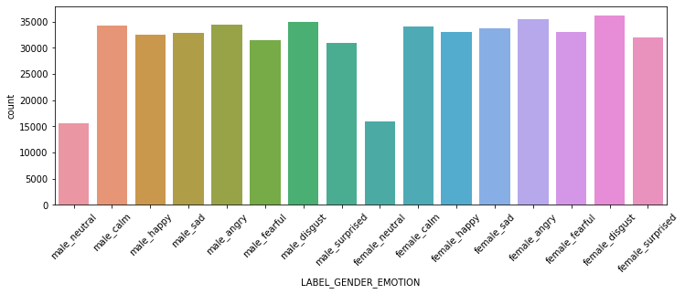

```python
# Dataset balance by gender + emotion
plt.figure(figsize = (12,4))
sns.countplot(x = 'LABEL_GENDER_EMOTION', data = df_final)
plt.xticks(rotation = 45)
```

# Machine Learning

## Model 1 - Predict Gender

```python
# Getting X values
x1 = df_final[df_final.columns[:-7]].values
```

```python
# Using Label Encoder to codify the genders
y1 = LabelEncoder().fit_transform(df_final['LABEL_GENDER'])
```

```python
# Train test split
x1_train, x1_test, y1_train, y1_test = train_test_split(x1, y1, test_size = 0.33, stratify = y1, shuffle = True)
```

```python
# Scale the training data
z_scaler = StandardScaler()

# First fit the scaler on the train dataset
fitted = z_scaler.fit(x1_train)

# Then transform both train and test data
x1_train = fitted.transform(x1_train)
x1_test = fitted.transform(x1_test)
```

```python
# Creating a dictionary with ML algorithms to be used
classifiers = {'XGboost':XGBClassifier(),
               'DecisonTree':DecisionTreeClassifier(),
               'RandomForest':RandomForestClassifier()}
```

```python
# Function to train each classifier and evaluate performance
def train_evaluate_gender(classifiers, x_train, x_test, y_train, y_test):

    # Loop through the classifiers dictionary
    for k, clf in classifiers.items():

        print("\nStarting training for model " + k + '...')

        # Train model
        clf.fit(x_train, y_train)

        # Predict
        y_pred = clf.predict(x_test)

        # Calculate accuracy
        acc = accuracy_score(y_test, y_pred)
        print(f'\nClassifier {k} has accuracy: {acc}')

        # Create Confusion Matrix
        cm = confusion_matrix(y_test, y_pred)
        print(f'\nConfusion Matrix')
        print(cm)

        # Save model to disk
        dump(clf, 'models/model_' + k + '_gender.joblib')
        print('\nModel ' + k + ' saved to disk')
```

```python
%%time

# Run the function to test all algorithms
train_evaluate_gender(classifiers, x1_train, x1_test, y1_train, y1_test)

print('\nTraining finished!')
```

```
Starting training for model XGboost...

Classifier XGboost has accuracy: 0.7899633544322966

Confusion Matrix
[[67804 15825]
 [18851 62615]]

Model XGboost saved to disk

Starting training for model DecisonTree...

Classifier DecisonTree has accuracy: 0.8299463945001363

Confusion Matrix
[[69716 13913]
 [14162 67304]]

Model DecisonTree saved to disk

Starting training for model RandomForest...

Classifier RandomForest has accuracy: 0.889487870619946

Confusion Matrix
[[73615 10014]
 [ 8231 73235]]

Model RandomForest saved to disk

Training finished!
Wall time: 5min 56s
```

## Model 2 - Predict Gender and Emotion

```python
# Getting X values
x2 = df_final[df_final.columns[:-7]].values
```

```python
# Using Label Encoder to codify the genders
y2 = LabelEncoder().fit_transform(df_final['LABEL_GENDER_EMOTION'])
```

```python
# Train test split
x2_train, x2_test, y2_train, y2_test = train_test_split(x2, y2, test_size = 0.33, stratify = y2, shuffle = True)
```

```python
# Scale the training data
z_scaler = StandardScaler()

# First fit the scaler on the train dataset
fitted2 = z_scaler.fit(x2_train)

# Then transform both train and test data
x2_train = fitted.transform(x2_train)
x2_test = fitted.transform(x2_test)
```

```python
# Function to train each classifier and evaluate performance
def train_evaluate_gender_emotion(classifiers, x_train, x_test, y_train, y_test):

    # Loop through the classifiers dictionary
    for k, clf in classifiers.items():

        print("\nStarting training for model " + k + '...')

        # Train model
        clf.fit(x_train, y_train)

        # Predict
        y_pred = clf.predict(x_test)

        # Calculate accuracy
        acc = accuracy_score(y_test, y_pred)
        print(f'\nClassifier {k} has accuracy: {acc}')

        # Create Confusion Matrix
        cm = confusion_matrix(y_test, y_pred)
        print(f'\nConfusion Matrix')
        print(cm)

        # Save model to disk
        dump(clf, 'models/model_' + k + '_gender_emotion.joblib')
        print('\nModel ' + k + ' saved to disk')
```

```python
%%time

# Run the function to test all algorithms
train_evaluate_gender_emotion(classifiers, x2_train, x2_test, y2_train, y2_test)

print('\nTraining finished!')
```

```
Starting training for model XGboost...

Classifier XGboost has accuracy: 0.2822193282655441

Confusion Matrix
[[4313  353  928 1059  888    5  335  987 1440   42  212  422  223    3
    68  404]
 [  94 7587  556   99   63   47  920  134   32 1083  177   74   57   13
   167  157]
 [1098 1794 2554  740  839   31 1036 1763   83  530  345  175  279   30
   192  440]
 [2066 1080  602 2870  806   19  514 1023  647   68  100  479  142    3
    82  380]
 [1911  888  917 1307 2157    8  850 1117  457  253  202  364  107   17
    85  281]
 [  49 2718  391   46   55  144  656  158   11  610  123   23   21   13
   105  149]
 [ 665 3512 1044  751  450   36 2238  587   35  623  260  150  160   10
   253  372]
 [1010 1064 1044  797  923   18  820 2937  209  118  191  264  178    2
   127  835]
 [1182  143  132  305  394    0  111  486 5005  418  567  642  628   10
   373  948]
 [   9 1382   85   78   15   10  242   96   38 7317  585   63  185   83
   933  196]
 [ 493  954  500  235  135    5  420  619  446 2099 2157  538  667   49
   963 1236]
 [ 735  349  266  555  166    5  411  545 1462 1208  722 1748  829   29
   739  614]
 [ 782  319  326  335  338    4  201  704  902 1355  823  896 1711   82
   902 1042]
 [   3  557  124    4    8    3  127  135   28 2441  276   20  172  135
   845  268]
 [ 146 1441  268  104  145    7  326  285  254 3382  647  553  555   58
  1843  815]
 [ 561  559  445  233  323    5  175  997  522 1316  883  591  861   79
   783 1877]]

Model XGboost saved to disk

```

[output cut: 67 more lines]

```
 [ 199  109  206  206  124   15  125  137  784  584  623 5870  482  110
   424  385]
 [ 206   91  197  122  127   25  127  226  496  678  582  427 6348  130
   387  553]
 [   9  125   70   15   14   31   77   41   19 1292  278   87  179 2297
   484  128]
 [  74  341  165   69   60   85  119  123  170 1732  554  313  386  217
  6069  352]
 [ 154  109  208  133  110   25  110  260  361  629  722  416  769  162
   535 5507]]

Model RandomForest saved to disk

Training finished!
Wall time: 29min 27s
```

```python
# Create a PCA object with 20 components
pca_20 = PCA(n_components = 20)
```

```python
# Using the x/y data from model 1, since it was also for gender prediction
x1_train.shape
```

```
(335191, 20)
```

```python
# Applying PCA to the training data
pca_feature = pca_20.fit(x1_train)
```

```python
pca_feature
```

```
PCA(n_components=20)
```

```
 <a list of 20 Text major ticklabel objects>)
```

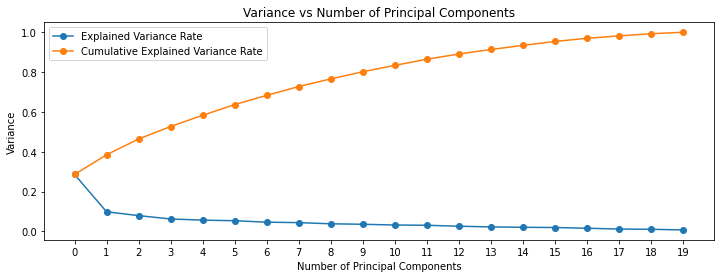

```python
# Plot
plt.figure(figsize = (12, 4))
plt.plot(pca_feature.explained_variance_ratio_, marker = 'o', label = 'Explained Variance Rate')
plt.plot(pca_feature.explained_variance_ratio_.cumsum(), marker = 'o', label = 'Cumulative Explained Variance Rate')
plt.legend()
plt.ylabel('Variance')
plt.xlabel('Number of Principal Components')
plt.title('Variance vs Number of Principal Components')
plt.xticks(np.arange(0, 20, step = 1))
```

```python
# Saving the components
components = pca_feature.fit_transform(x1_train)
```

```python
# Visualize
components
```

```
array([[ 0.81793505,  2.2289948 ,  6.551832  , ...,  0.7566632 ,
         1.2090428 , -0.55567753],
       [-0.406427  , -3.8125827 ,  0.01774758, ..., -0.41411147,
         0.5542691 , -0.3927645 ],
       [-1.6900054 , -0.26272348, -0.10464392, ...,  0.20780295,
        -0.09791111,  0.17072834],
       ...,
       [-2.2944653 , -0.7926662 , -1.0375288 , ...,  0.08214777,
        -0.09014749,  0.46862382],
       [-1.5170457 ,  0.3078449 , -0.2936892 , ...,  0.10762074,
         0.01201031, -0.10196748],
       [ 0.74866325,  1.5854828 , -0.6777546 , ..., -0.4836019 ,
        -0.3262427 , -0.14921625]], dtype=float32)
```

```python
# Check type
type(components)
```

```
numpy.ndarray
```

```python
# Converting the array to dataframe
components_df = pd.DataFrame(components)
```

```python
# Adjusting index
components_df.index = pd.RangeIndex(start = 0, stop = len(components_df.index), step = 1)
```

```python
# View
components_df.head()
```

|  | 0 | 1 | 2 | 3 | 4 | 5 | 6 | 7 | 8 | 9 | 10 | 11 | 12 | 13 | 14 | 15 | 16 | 17 | 18 | 19 |
| --- | --- | --- | --- | --- | --- | --- | --- | --- | --- | --- | --- | --- | --- | --- | --- | --- | --- | --- | --- | --- |
| 0 | 0.817935 | 2.228995 | 6.551832 | 0.919350 | -1.157539 | -2.351449 | 1.184773 | 1.623234 | 0.657935 | -2.205470 | -0.191457 | 0.061119 | -1.102526 | -0.151148 | -1.937881 | -0.743959 | -0.989330 | 0.756663 | 1.209043 | -0.555678 |
| 1 | -0.406427 | -3.812583 | 0.017748 | -0.988423 | 0.166966 | -0.300564 | -0.527874 | 1.114727 | 0.379517 | -0.959077 | 0.783221 | -0.439352 | -0.050427 | 0.330571 | 0.413873 | 0.398849 | 0.401881 | -0.414111 | 0.554269 | -0.392765 |
| 2 | -1.690005 | -0.262723 | -0.104644 | -0.741844 | 0.059906 | 1.094772 | -0.471815 | -0.135232 | 0.029346 | -1.054106 | 0.362792 | -0.680469 | -0.535968 | 0.015750 | -0.052635 | -0.473981 | 0.013689 | 0.207803 | -0.097911 | 0.170728 |
| 3 | -2.169122 | 0.356323 | -0.581886 | 0.061808 | -0.007264 | -0.296470 | -0.004363 | -0.224322 | 0.181942 | 0.377460 | -0.008394 | 0.583931 | 0.728293 | -0.252462 | -0.133282 | 0.010115 | -0.112256 | 0.037229 | 0.023215 | 0.079963 |
| 4 | 4.793149 | 0.911040 | -0.500708 | 0.387858 | -1.655834 | 2.818822 | -0.676771 | -0.806656 | 1.783190 | 1.705665 | 0.195869 | 0.802911 | -4.034620 | -2.135656 | 1.371211 | -0.161348 | -1.030812 | -0.592246 | 0.279889 | -0.230941 |

```python
# Extracting the top 15 components
x_train_pca = components_df[components_df.columns[0:15]].values
```

```python
# Setting y
y_train_pca = y1_train
```

```python
# For test data, using from model 1
x_test_pca = x1_test
y_test_pca = y1_test
```

```python
len(x_train_pca)
```

```
335191
```

```python
len(y_train_pca)
```

```
335191
```

```python
len(x_test_pca)
```

```
165095
```

```python
len(y_test_pca)
```

```
165095
```

```python
# Function to train each classifier and evaluate performance
def train_evaluate_gender_pca(classifiers, x_train, x_test, y_train, y_test):

    # Loop through the classifiers dictionary
    for k, clf in classifiers.items():

        print("\nStarting training for model " + k + '...')

        # Train model
        clf.fit(x_train, y_train)

        # Predict
        y_pred = clf.predict(x_test)

        # Calculate accuracy
        acc = accuracy_score(y_test, y_pred)
        print(f'\nClassifier {k} has accuracy: {acc}')

        # Create Confusion Matrix
        cm = confusion_matrix(y_test, y_pred)
        print(f'\nConfusion Matrix')
        print(cm)

        # Save model to disk
        dump(clf, 'models/model_' + k + '_gender_pca.joblib')
        print('\nModel ' + k + ' saved to disk')
```

```python
%%time

# Run the function to test all algorithms
train_evaluate_gender_pca(classifiers, x2_train, x2_test, y2_train, y2_test)

print('\nTraining finished!')
```

```
Starting training for model XGboost...

Classifier XGboost has accuracy: 0.2822193282655441

Confusion Matrix
[[4313  353  928 1059  888    5  335  987 1440   42  212  422  223    3
    68  404]
 [  94 7587  556   99   63   47  920  134   32 1083  177   74   57   13
   167  157]
 [1098 1794 2554  740  839   31 1036 1763   83  530  345  175  279   30
   192  440]
 [2066 1080  602 2870  806   19  514 1023  647   68  100  479  142    3
    82  380]
 [1911  888  917 1307 2157    8  850 1117  457  253  202  364  107   17
    85  281]
 [  49 2718  391   46   55  144  656  158   11  610  123   23   21   13
   105  149]
 [ 665 3512 1044  751  450   36 2238  587   35  623  260  150  160   10
   253  372]
 [1010 1064 1044  797  923   18  820 2937  209  118  191  264  178    2
   127  835]
 [1182  143  132  305  394    0  111  486 5005  418  567  642  628   10
   373  948]
 [   9 1382   85   78   15   10  242   96   38 7317  585   63  185   83
   933  196]
 [ 493  954  500  235  135    5  420  619  446 2099 2157  538  667   49
   963 1236]
 [ 735  349  266  555  166    5  411  545 1462 1208  722 1748  829   29
   739  614]
 [ 782  319  326  335  338    4  201  704  902 1355  823  896 1711   82
   902 1042]
 [   3  557  124    4    8    3  127  135   28 2441  276   20  172  135
   845  268]
 [ 146 1441  268  104  145    7  326  285  254 3382  647  553  555   58
  1843  815]
 [ 561  559  445  233  323    5  175  997  522 1316  883  591  861   79
   783 1877]]

Model XGboost saved to disk

```

[output cut: 67 more lines]

```
 [ 214  114  191  197  121   11  155  156  777  555  630 5796  524  105
   433  404]
 [ 204  105  175  126  123   30  106  229  511  625  600  434 6355  144
   420  535]
 [  12  140   75    8   13   36   80   40   24 1276  261   99  160 2316
   459  147]
 [  77  361  168   73   66   81  116  118  154 1748  551  324  376  204
  6032  380]
 [ 161  116  192  119  106   34  102  264  387  618  680  439  779  156
   508 5549]]

Model RandomForest saved to disk

Training finished!
Wall time: 30min 56s
```